# Chemical Structures of PCBs congeners

6.1

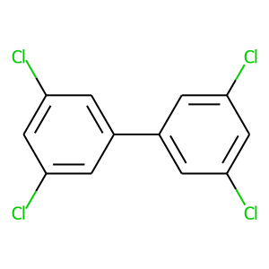

3,4,4',5-Tetrachlorobiphenyl

70362-50-4

C12H6Cl4

6.6

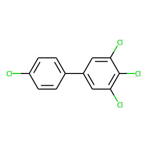

2,2',3,3',4-Pentachlorobiphenyl

52663-62-4

C12H5Cl5

6.7

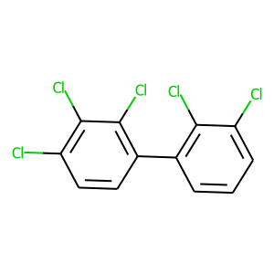

2,2',3,3',5-Pentachlorobiphenyl

60145-20-2

C12H5Cl5

6.8

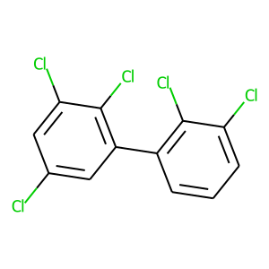

2,2',3,3',6-Pentachlorobiphenyl

52663-60-2

C12H5Cl5

6.0

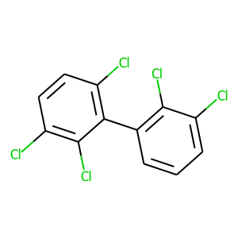

2,2',3,4,4'-Pentachlorobiphenyl

65510-45-4

C12H5Cl5

6.6

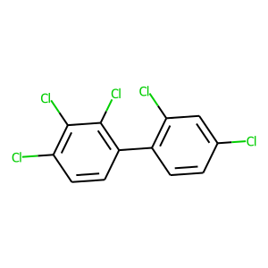

2,2',3,4,5-Pentachlorobiphenyl

55312-69-1

C12H5Cl5

6.7

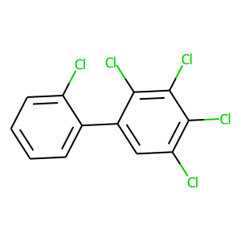

2,2',3,4,5'-Pentachlorobiphenyl

38380-02-8

C12H5Cl5

6.4

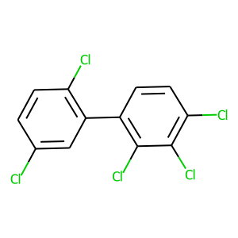

2,2',3,4,6-Pentachlorobiphenyl

55215-17-3

C12H5Cl5

6.3

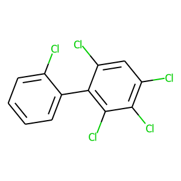

2,2',3,4,6'-Pentachlorobiphenyl

73575-57-2

C12H5Cl5

6.3

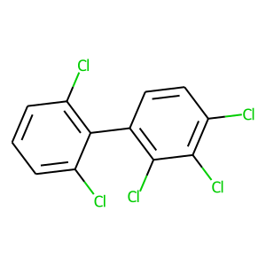

2,2',3,4',5-Pentachlorobiphenyl

68194-07-0

C12H5Cl5

6.8

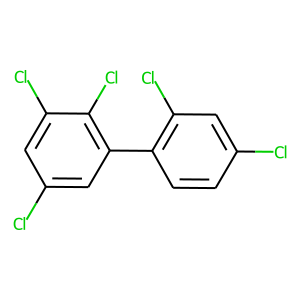

2,2',3,4',6-Pentachlorobiphenyl

68194-05-8

C12H5Cl5

6.3

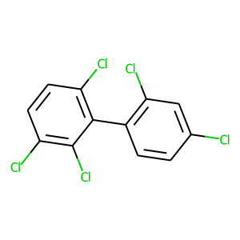

2,2',3,5,5'-Pentachlorobiphenyl

52663-61-3

C12H5Cl5

7.0

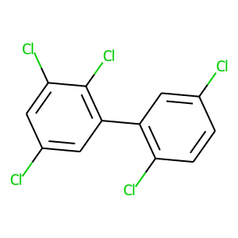

2,2',3,5,6-Pentachlorobiphenyl

73575-56-1

C12H5Cl5

6.2

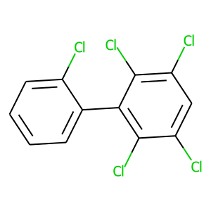

2,2',3,5,6'-Pentachlorobiphenyl

73575-55-0

C12H5Cl5

6.2

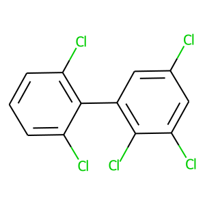

2,2',3,5',6-Pentachlorobiphenyl

38379-99-6

C12H5Cl5

6.5

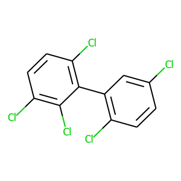

2,2',3,6,6'-Pentachlorobiphenyl

73575-54-9

C12H5Cl5

6.1

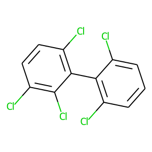

2,2',3,4',5'-Pentachlorobiphenyl

41464-51-1

C12H5Cl5

6.7

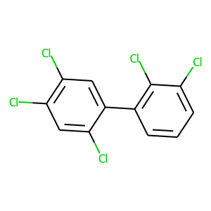

2,2',3,4',6'-Pentachlorobiphenyl

60233-25-2

C12H5Cl5

6.3

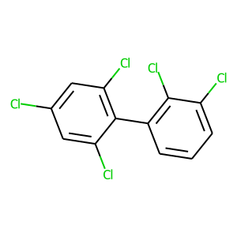

2,2',4,4',5-Pentachlorobiphenyl

38380-01-7

C12H5Cl5

7.2

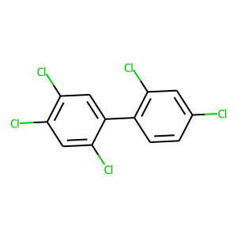

2,2',4,4',6-Pentachlorobiphenyl

39485-83-1

C12H5Cl5

6.3

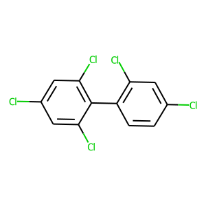

2,2',4,5,5'-Pentachlorobiphenyl

37680-73-2

C12H5Cl5

6.5

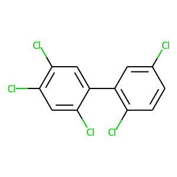

2,2',4,5,6'-Pentachlorobiphenyl

68194-06-9

C12H5Cl5

6.3

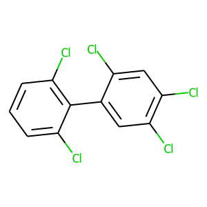

2,2',4,5',6-Pentachlorobiphenyl

60145-21-3

C12H5Cl5

6.2

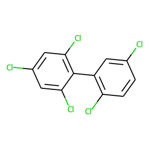

2,2',4,6,6'-Pentachlorobiphenyl

56558-16-8

C12H5Cl5